[figure not shown]

# Introduction to Scikit-learn

Kannan Singaravelu

kannan.singaravelu@fitchlearning.com

# Scikit-learn

Scikit-learn or `sklearn` is the most popular Python package for machine learning. The project started as scikits.learn, a Google Summer of Code project in 2007 by David Cournapeau. It was orginially developed as separate SciPy Toolkit - a third-party extension to Scipy and hence then name Scikit.

The original codebase was later rewritten by other developers and in 2010 Fabian Pedregosa, Gael Varoquaux, Alexandre Gramfort and Vincent Michel, all from FIRCA - French Institute for Research in Computer Science and Automation - took this project to the next level and made the first public release in February 2010.

Scikit-learn has a slew of machine learning models and provides functions that are needed for a data science workflow. These includes tools for data preprocessing, model selection, model fitting and evaluation among many other utilities. It features various classification, regression, clustering and dimensionality reduction algorithms including support vector machines, random forests, gradient boosting, k-means and DBSCAN.

Scikit-learn makes working with complicated machine learning workflows for small and medium datasets a breeze with its powerful **API**. It is built upon NumPy, SciPy and matplotlib libraries, which enable efficient in-core numerical and scientific computation.

## Data Science Workflow

The data science workflow is essentially a seven steps process from ideation to validation. The goal of such practice is to enable data-driven decisions. There is no standard template for solving a data science problem as every problem can be different. However, we do follow similar steps for each of these problems.

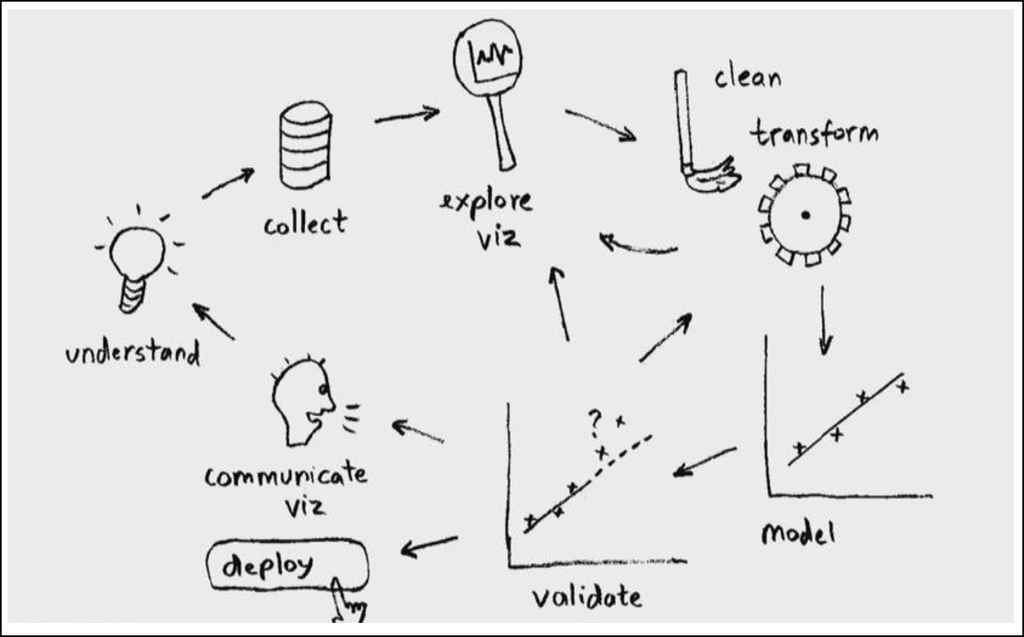

Representation of Data Science Workflow

## Installation

```
# Scikit-learn is shipped with Ananconda distribution.
# For new installation, use either pip or conda.

# Using pip
pip install scikit-learn

# Using conda
conda install scikit-learn
```

## Import Package

`Scikit-learn` relies heavily on object-oriented programming principles. It implements machine learning algorithms as classes and objects are created from these classes.

```
# To import whole library
import sklearn

# To import particular classes or methods of class objects

# loading dataset
from sklearn.datasets import fetch_california_housing
from sklearn.model_selection import train_test_split

# data preprocessing
from sklearn.preprocessing import StandardScaler
from sklearn.pipeline import Pipeline
from sklearn.feature_selection import SelectKBest
```

```
# selecting the estimator
from sklearn.linear_model import LogisticRegression
from sklearn.ensemble import RandomForestClassifier
from sklearn.cluster import k_means

# selecting the metrics
from sklearn.metrics import accuracy_score
from sklearn.metrics import mean_squared_error
```